# Lab 04 - La Quinta is Spanish for next to Denny’s, Pt. 1

Ben Waggener 2/07/2025

### Load packages and data

```r
library(tidyverse)
library(dsbox)
library(viridis)
states <- read_csv("data/states.csv")
```

### Exercise 1

“What are the dimensions of the Denny’s dataset? (Hint: Use inline R code and functions like nrow and ncol to compose your answer.) What does each row in the dataset represent? What are the variables?”

```r
glimpse(dennys)
```

```
## Rows: 1,643
## Columns: 6
## $ address   <chr> "2900 Denali", "3850 Debarr Road", "1929 Airport Way", "230 …
## $ city      <chr> "Anchorage", "Anchorage", "Fairbanks", "Auburn", "Birmingham…
## $ state     <chr> "AK", "AK", "AK", "AL", "AL", "AL", "AL", "AL", "AL", "AL", …
## $ zip       <chr> "99503", "99508", "99701", "36849", "35207", "35294", "35056…
## $ longitude <dbl> -149.8767, -149.8090, -147.7600, -85.4681, -86.8317, -86.803…
## $ latitude  <dbl> 61.1953, 61.2097, 64.8366, 32.6033, 33.5615, 33.5007, 34.206…
```

```r
nrow(dennys)
```

```
## [1] 1643
```

```r
ncol(dennys)
```

```
## [1] 6
```

There are 1,643 rows in the Dennys dataset which represents individual Dennys locations. There are 6 columns which represents the variables that describe the location.

### Exercise 2

“What are the dimensions of the La Quinta’s dataset? What does each row in the dataset represent? What are the variables?”

```r
glimpse(laquinta)
```

```
## Rows: 909
## Columns: 6
## $ address   <chr> "793 W. Bel Air Avenue", "3018 CatClaw Dr", "3501 West Lake …
## $ city      <chr> "\nAberdeen", "\nAbilene", "\nAbilene", "\nAcworth", "\nAda"…
## $ state     <chr> "MD", "TX", "TX", "GA", "OK", "TX", "AG", "TX", "NM", "NM", …
## $ zip       <chr> "21001", "79606", "79601", "30102", "74820", "75254", "20345…
## $ longitude <dbl> -76.18846, -99.77877, -99.72269, -84.65609, -96.63652, -96.8…
## $ latitude  <dbl> 39.52322, 32.41349, 32.49136, 34.08204, 34.78180, 32.95164, …
```

```r
nrow(laquinta)
```

```
## [1] 909
```

```r
ncol(laquinta)
```

```
## [1] 6
```

There are 909 rows in the La Quinta dataset which represent individual La Quintas. There are 6 columns that represent the variables that describe the location of each hotel.

### Exercise 3

Looking at the webpages, I saw that there are no Dennys outside of the United States while there are La Quintas outside of the United States.

This includes locations Canada, Mexico, China, New Zealand, Turkey, UAE, Chile, Colombia, and Ecuador. …

### Exercise 4

Filtering using the state variable might be the best way to tell if there are locations outside of the US because as far as I can tell these are unique to America. For a rough method maybe you could set a boundary with the lines of longitude and latitude but I don’t know if that would be precise enough to capture the entire United states and not accidentally include hotels in Mexico or Canada.

### Exercise 5

“Find the Denny’s locations that are outside the US, if any. To do so, filter the Denny’s locations for observations where state is not in states$abbreviation. The code for this is given below. Note that the %in% operator matches the states listed in the state variable to those listed in states$abbreviation. The ! operator means not. Are there any Denny’s locations outside the US?”

```r
dennys %>%
  filter(!(state %in% states$abbreviation))
```

```
## # A tibble: 0 × 6
## # ℹ 6 variables: address <chr>, city <chr>, state <chr>, zip <chr>,
## #   longitude <dbl>, latitude <dbl>
```

There are no Denny’s locations outside of the US. …

### Exercise 6

“Add a country variable to the Denny’s dataset and set all observations equal to”United States”. Remember, you can use the mutate function for adding a variable. Make sure to save the result of this as dn again so that the stored data frame contains the new variable going forward.”

```r
dn <- dennys %>%
  mutate(country = "United States")
```

### Exercise 7

“Find the La Quinta locations that are outside the US, and figure out which country they are in. This might require some googling. Take notes, you will need to use this information in the next exercise.”

Using this website https://www.wyndhamhotels.com/laquinta/locations i was able to find all of the La Quinta locations outside of the US. They are in Canada, Mexico, China, New Zealand, Turkey, UAE, Chile, Colombia, and Ecuador.

### Exercise 8

“Add a country variable to the La Quinta dataset. Use the case_when function to populate this variable. You’ll need to refer to your notes from Exercise 7 about which country the non-US locations are in.”

```r
lq <- laquinta %>%
  mutate(country = case_when(
    state %in% state.abb ~ "United States",
    state %in% c("ON", "BC") ~ "Canada",
    state == "ANT" ~ "Colombia",
    city == "Oshawa" ~ "Canada",
   state %in% c("CH", "AG", "SL") ~ "Mexico",
   city == "San Luis Potosi" ~ "Mexico",
    city == "Ciudad Juarez" ~ "Mexico",
    city == "Poza Rica" ~ "Mexico",
    city == "Puebla" ~ "Mexico",
     city == "Reynosa" ~ "Mexico",
     city == "San Jose Chiapa" ~ "Mexico",
     city == "Col Partido Iglesias Juarez" ~ "Mexico",
    city == "Qionghai" ~ "China",
    city == "Taiyuan" ~ "China",
    city == "Weifang" ~ "China",
    city == "Zunyi" ~ "China",
    city == "Auckland" ~ "New Zealand",
    city == "Queenstown" ~ "New Zealand",
    city == "Bodrum" ~ "Turkey",
    city == "Cesme" ~ "Turkey",
    city == "Giresun" ~ "Turkey",
    city == "Istanbul" ~ "Turkey",
    city == "Abu Dhabi" ~ "UAE",
    city == "Dubai" ~ "UAE",
    city == "Santiago" ~ "Chile",
    city == "Medellin" ~ "Colombia",
    city == "Quito" ~ "Ecuador",
    TRUE ~ NA_character_
  ))
```

prep for ex 9 filtering out non US hotels

```r
lq <- lq %>%
  filter(country == "United States")
```

### Exercise 9

“Which states have the most and fewest Denny’s locations? What about La Quinta? Is this surprising? Why or why not?”

```r
dn %>%
  count(state) %>%
  arrange(desc(n))
```

```
## # A tibble: 51 × 2
##    state     n
##    <chr> <int>
##  1 CA      403
##  2 TX      200
##  3 FL      140
##  4 AZ       83
##  5 IL       56
##  6 NY       56
##  7 WA       49
##  8 OH       44
##  9 MO       42
## 10 PA       40
## # ℹ 41 more rows
```

```r
lq %>%
  count(state) %>%
  arrange(desc(n))
```

```
## # A tibble: 48 × 2
##    state     n
##    <chr> <int>
##  1 TX      237
##  2 FL       74
##  3 CA       56
##  4 GA       41
##  5 TN       30
##  6 OK       29
##  7 LA       28
##  8 CO       27
##  9 NM       19
## 10 NY       19
## # ℹ 38 more rows
```

Prep for exercise 10 “Next, let’s calculate which states have the most Denny’s locations per thousand square miles. This requires joinining information from the frequency tables you created in the previous set with information from the states data frame.

First, we count how many observations are in each state, which will give us a data frame with two variables: state and n. Then, we join this data frame with the states data frame. However note that the variables in the states data frame that has the two-letter abbreviations is called abbreviation. So when we’re joining the two data frames we specify that the state variable from the Denny’s data should be matched by the abbreviation variable from the states data”

```r
dn %>%
  count(state) %>%
  inner_join(states, by = c("state" = "abbreviation"))
```

```
## # A tibble: 51 × 4
##    state     n name                     area
##    <chr> <int> <chr>                   <dbl>
##  1 AK        3 Alaska               665384.
##  2 AL        7 Alabama               52420.
##  3 AR        9 Arkansas              53179.
##  4 AZ       83 Arizona              113990.
##  5 CA      403 California           163695.
##  6 CO       29 Colorado             104094.
##  7 CT       12 Connecticut            5543.
##  8 DC        2 District of Columbia     68.3
##  9 DE        1 Delaware               2489.
## 10 FL      140 Florida               65758.
## # ℹ 41 more rows
```

```r
lq %>%
  count(state) %>%
  inner_join(states, by = c("state" = "abbreviation"))
```

```
## # A tibble: 48 × 4
##    state     n name           area
##    <chr> <int> <chr>         <dbl>
##  1 AK        2 Alaska      665384.
##  2 AL       16 Alabama      52420.
##  3 AR       13 Arkansas     53179.
##  4 AZ       18 Arizona     113990.
##  5 CA       56 California  163695.
##  6 CO       27 Colorado    104094.
##  7 CT        6 Connecticut   5543.
##  8 FL       74 Florida      65758.
##  9 GA       41 Georgia      59425.
## 10 IA        4 Iowa         56273.
## # ℹ 38 more rows
```

### Exercise 10

“Which states have the most Denny’s locations per thousand square miles? What about La Quinta? Next, we put the two datasets together into a single data frame. However before we do so, we need to add an identifier variable. We’ll call this establishment and set the value to”Denny’s” and “La Quinta” for the dn and lq data frames, respectively.”

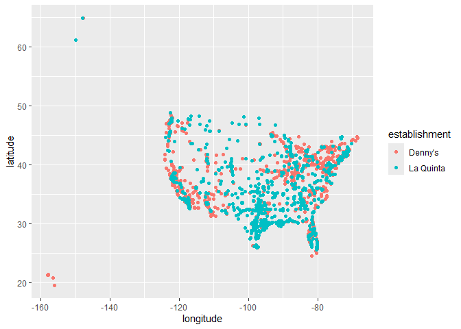

```r
dn <- dn %>%
  mutate(establishment = "Denny's")
lq <- lq %>%
  mutate(establishment = "La Quinta")

dn_lq <- bind_rows(dn, lq)

ggplot(dn_lq, mapping = aes(
  x = longitude,
  y = latitude,
  color = establishment
)) +
  geom_point()
```

### Exercise 11 “Filter the data for observations in North Carolina only, and recreate the plot. You should also adjust the transparency of the points, by setting the alpha level, so that it’s easier to see the overplotted ones. Visually, does Mitch Hedberg’s joke appear to hold here?”

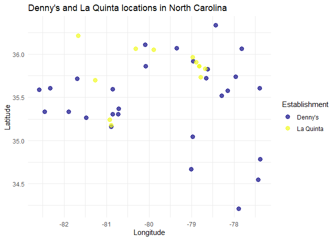

```r
dn_lq %>%
  filter(state == "NC") %>%
  ggplot(mapping = aes(
    x = longitude,
    y = latitude,
    color = establishment
  )) +
  geom_point(alpha = 0.7, size = 3) +
  scale_color_viridis_d(option = "plasma") +
  theme_minimal() +
  labs(
    title = "Denny's and La Quinta locations in North Carolina",
    x = "Longitude",
    y = "Latitude",
    color = "Establishment"
  ) +
  theme(
    legend.position = "right"
  )
```

Visually, it is hard to tell if the joke holds true statistically because there are far more Denny’s locations than La Quinta locations. However, most of the La Quinta locations are near or overlapping with Dennys locations.

### Exercise 12

“Now filter the data for observations in Texas only, and recreate the plot, with an appropriate alpha level. Visually, does Mitch Hedberg’s joke appear to hold here?”

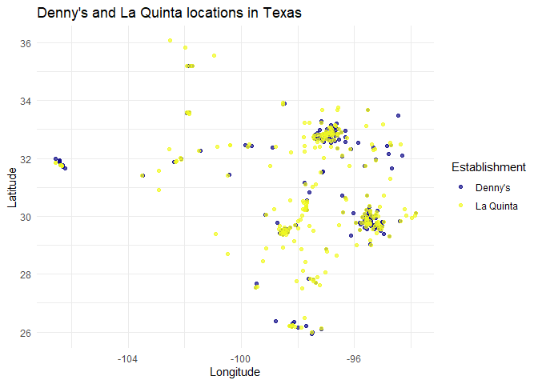

```r
dn_lq %>%
  filter(state == "TX") %>%
  ggplot(mapping = aes(
    x = longitude,
    y = latitude,
    color = establishment
  )) +
  geom_point(alpha = 0.7, size = 1.5) +
  scale_color_viridis_d(option = "plasma") +
  theme_minimal() +
  labs(
    title = "Denny's and La Quinta locations in Texas",
    x = "Longitude",
    y = "Latitude",
    color = "Establishment"
  ) +
  theme(
    legend.position = "right"
  )
```

Again, it is hard to tell if the joke holds true because there are more of one establishment than the other (this time it is La Quintas). However, most of the Dennys locations are clustered around the La Quinta locations supporting the joke.

Though it also seem that these are all clustered around large cities in Texas, such as Dallas in the northern part of the state, Houston in the south east part of the state, etc.